# Динамика физиологических показателей на фоне развития заболевания

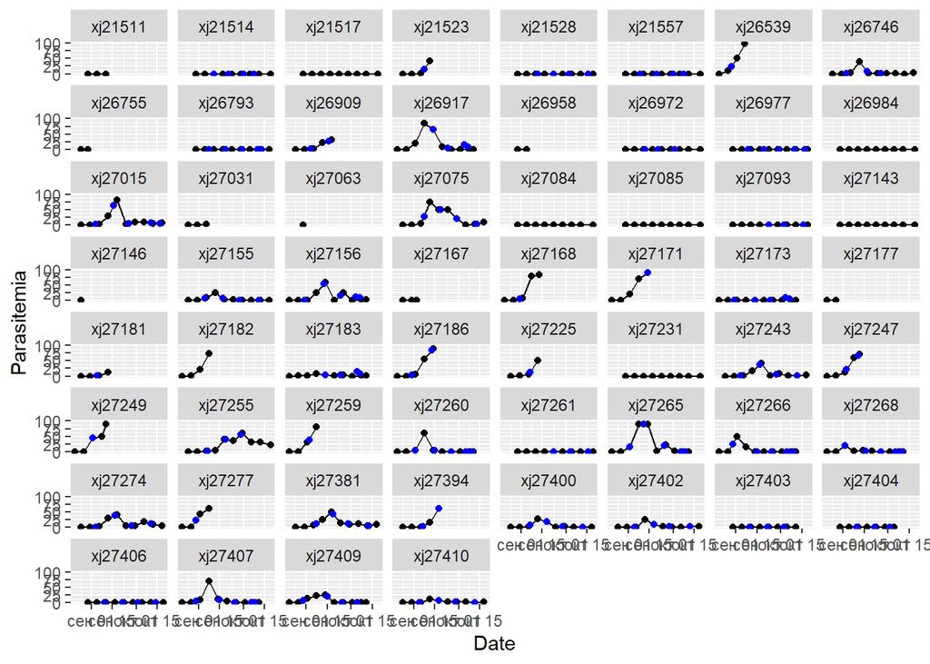

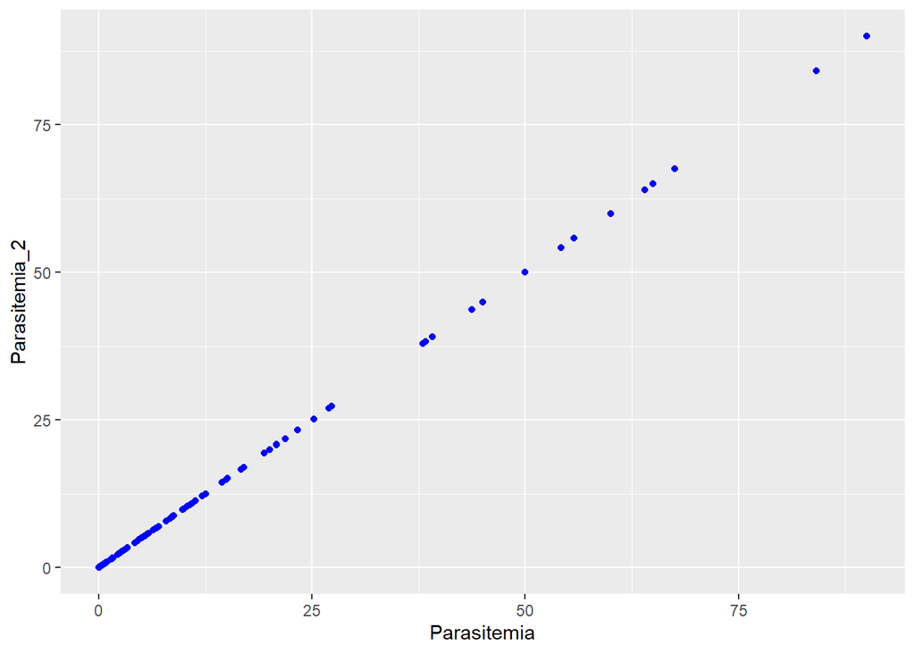

# Первый этап анализа

Описание динамики физиологических показателей в процессе развития заболевания

## Динамика RMR на фоне развития заболевания

Необходимо рассмотреть две модели. 1. Модель с общим смузером для всех трех групп (Cont, Exp1, Exp2); 2. Модель, где для каждой группы будет подобран свой смузер.

Если лучше окажется модель №1, то это будет означать, что RMR изменяется одинаково по ходу наблюдений. Если выигрывает модель №2, то это означает, что динамика RMR будет разной для каждой из групп.

Вот эти две модели

```r
M1_RMR_gam <- gam(log(RMR) ~ s(DPI) + Experiment + log(Mass)  + s(Ring, k = 53, bs = "re"),  method = "REML", data = finch_reduced)


M2_RMR_gam <- gam(log(RMR) ~ s(DPI, by = Experiment) + Experiment + log(Mass)  + s(Ring, k = 53, bs = "re"),  method = "REML", data = finch_reduced)
```

```r
AIC(M1_RMR_gam, M2_RMR_gam)
```

```
##                  df       AIC
## M1_RMR_gam 31.52285 -257.8777
## M2_RMR_gam 43.27718 -294.9823
```

Будем рассматривать модель №2.

Проверка ее валидности

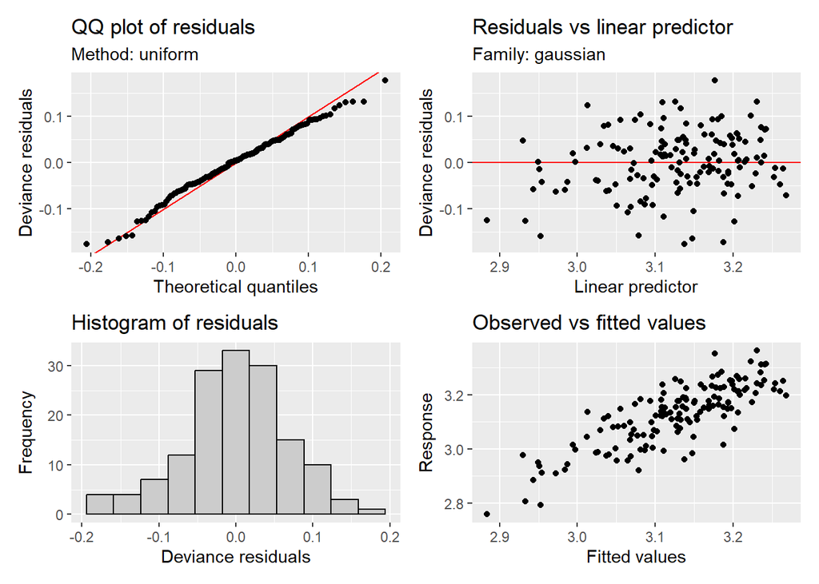

### Описание модели

```
##
## Family: gaussian
## Link function: identity
##
## Formula:
## log(RMR) ~ s(DPI, by = Experiment) + Experiment + log(Mass) +
##     s(Ring, k = 53, bs = "re")
##
## Parametric coefficients:
##                Estimate Std. Error t value Pr(>|t|)
## (Intercept)     1.94400    0.28437   6.836 4.30e-10 ***
## ExperimentExp1 -0.04434    0.02735  -1.621    0.108
## ExperimentExp2  0.01196    0.02802   0.427    0.670
## log(Mass)       0.46969    0.11140   4.216 5.01e-05 ***
## ---
## Signif. codes:  0 '***' 0.001 '**' 0.01 '*' 0.05 '.' 0.1 ' ' 1
##
## Approximate significance of smooth terms:
##                          edf Ref.df      F  p-value
## s(DPI):ExperimentCont  1.093  1.179  3.671   0.0432 *
## s(DPI):ExperimentExp1  1.075  1.143 40.930  < 2e-16 ***
## s(DPI):ExperimentExp2  3.421  4.071  6.494 9.69e-05 ***
## s(Ring)               24.928 42.000  1.699 7.82e-06 ***
## ---
## Signif. codes:  0 '***' 0.001 '**' 0.01 '*' 0.05 '.' 0.1 ' ' 1
##
## R-sq.(adj) =  0.559   Deviance explained = 65.9%
## -REML = -128.24  Scale est. = 0.0057978  n = 148
```

### Визуализации модели

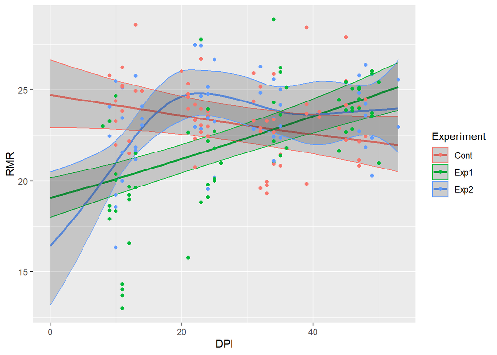

### Попарное сравнение смузеров.

На картинках, показанных ниже, приведены смузеры для разниц между группами. Если CI не включает ноль, то это означает, что разница значимая (в принципе, это все можно увидеть и на визуализации модели, которая приведена выше).

**NB!** Для longitudinal survey, которым является данное исследование, простые постхоки годятся лишь ограниченно (в принципе, можно сравнить попарно друг с другом Cont, Exp1 и Exp2, как бы вынеся динамику за скобки). Гораздо более правильным является сравнение смузеров для каждой из групп. Имея коэффициенты модели, можно построить “модель” поведения разности двух смузеров. Идея рисовать смузеры с CI для разностей - штука очевидная, но как это написать, чтобы получить картинки, я понял только сейчас. Техническая суть идеи изложена вот этом посте небезызвестного Симпсона https://fromthebottomoftheheap.net/2017/10/10/difference-splines-i/.

Вот еще очень внятная статья, в которой хорошо, со всеми ссылками, рассказано про применение GAM в медицинских longitudinal survey и дается сравнение с традиционными для медицины методами: https://doi.org/10.1002/sim.9505. *By the way*… Обратите внимание, что статья совсем свежая. То есть в человеческой медицине методы, которые мы предлагаем в работе с заболеваниями птиц - это новые идеи (что странно). Но этот аспект может быть нелишним для упоминания в статье.

Картинки получились, по-моему, внятные, но пока смотрим на них с осторожным оптимизмом, так как я еще не до конца понял теорию их построения. Пока еще изучаю матчасть. Может все не так просто и где-то я еще не усмотрел второе дно.

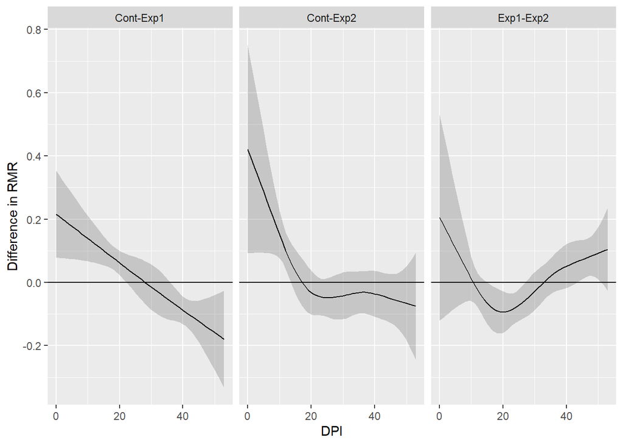

Если я не налажал где-то, то, согласно полученной картинке, RMR при заражении Exp1 в начале заболевания становится ниже, чем в контроле (это видно и из визуализации модели). Это все происходит в течение 0, 22 дней с начала наблюдений. Потом же RMR в группе Exp1 значимо превышает контроль. В случае с Exp2, аналогично, идет падение относительно контроля в начале заболевания (это происходит на 0, 13 день), но потом значимых отличий от контроля нет (хотя тенденция та же, что и в предыдущем случае).

## Динамика интрелейкина

```r
M1_IL_gam <- gam(log(IL6_pg_ml) ~ s(DPI, k = 5) + Experiment  + s(Ring, k = 53, bs = "re"),  method = "REML", data = finch_il)

M2_IL_gam <- gam(log(IL6_pg_ml) ~ s(DPI, by = Experiment, k = 5) + Experiment  + s(Ring, k = 53, bs = "re"),  method = "REML", data = finch_il)
```

```r
AIC(M1_IL_gam, M2_IL_gam)
```

```
##                 df      AIC
## M1_IL_gam 29.21474 459.5093
## M2_IL_gam 42.32431 357.3457
```

Аналогично, оптимальной будет модель с разными смузерами для каждой из групп.

Вот проверка ее валидности

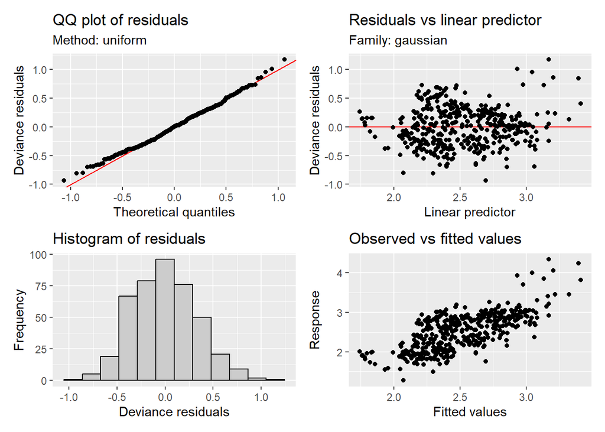

Визуализация этой модели

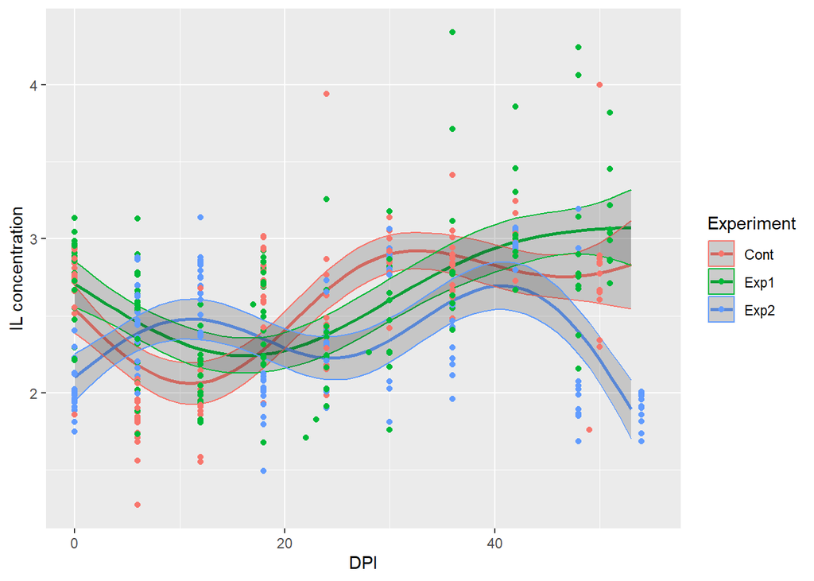

Честно говоря, я в этом, пока, никакой логики не вижу. Почему в контроле интерлейкины изменчивы?

Попарное сравнение смузеров дает еще более странную картину…Надо думать и обсуждать…

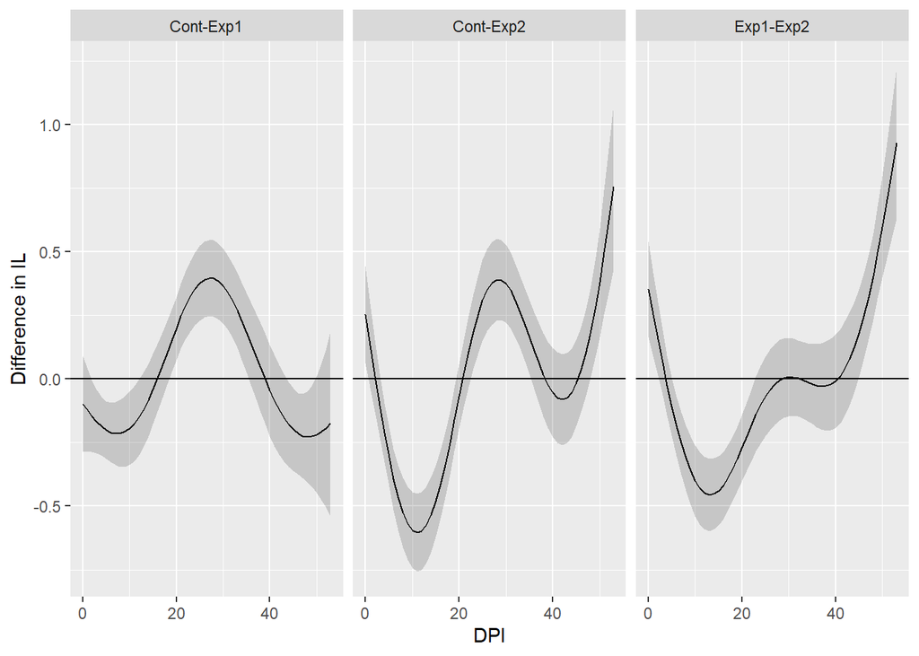

Пока я вижу следующее.  
1. При обеих инфекциях на первых порах интерлейкины становятся больше чем в контроле (смузер для разницы лежит в отрицательной области).

2. Но на следующей стадии, почему-то, количество интерлейкинов и при Exp1, и при Exp2 становится меньше, чем в контроле (смузер разности переходит в положительную зону). Подавление иммунитета?
3. На следующей стадии иммунный ответ на две инфекции имеет разный характер. Как это трактовать непонятно… При заражении Exp1 интерлейкинов выделяется больше, чем в контроле, а при заражении Exp2, наоборот меньше.
4. При сравнении Exp1 vs Exp2 создается впечатление, что в начале заболевания больше ыделяется интерелейкинов в ответ на Exp2, но на более поздних стадиях больше интерлейкинов в ответ на Exp1. Может это более ранний иммунный ответ на Exp2 и более поздний на Exp1?

# Второй этап анализа

Описание динамики гемипопуляции паразитов

## Динамика паразитемии

```r
M1_Par_gam <- gam(Parasitemia ~ s(DPI) + Experiment  + s(Ring, k = 53, bs = "re"),  method = "REML", data = finch_il %>% filter(Experiment != "Cont"), family = "nb")

M2_Par_gam <- gam(Parasitemia ~ s(DPI, by = Experiment) + Experiment  + s(Ring, k = 53, bs = "re"),  method = "REML", data = finch_il %>% filter(Experiment != "Cont"), family = "nb")
```

Обратите внимание, что в моделях используется отрицательное биномиальное распределение, так как моделируем *число* мерозоитов (то есть дискретную величину, которая не может быть ниже нуля).

```r
AIC(M1_Par_gam, M2_Par_gam)
```

```
##                  df      AIC
## M1_Par_gam 38.53825 1362.628
## M2_Par_gam 43.91247 1326.444
```

Разные смузеры для групп лучше. То есть ход развития инфекции несколько различен в разных группах

Проверка валидности

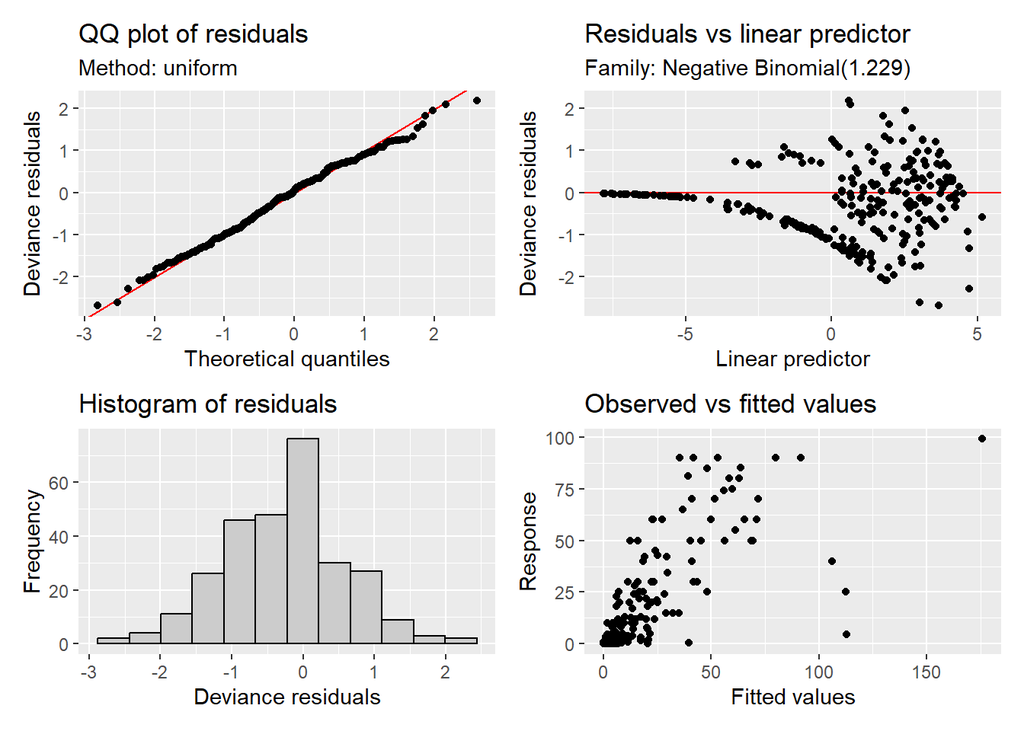

Визуализация модели

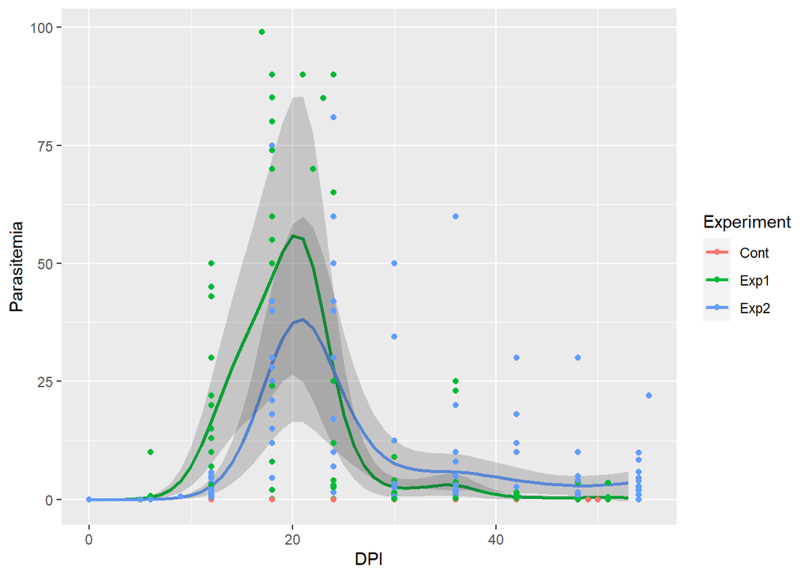

Тут все более или менее очевидно. Сначала идет рост численности гемипопуляции паразита, после пика численности происходит ее снижение (излечение). Видно, что при заражении Exp2 пик заболевания немного смещен, то есть всплеск мерогонии происходит чуть позднее.

Сравнение смузеров дает вполне трактуемую картинку. Exp1 дает больше мерозоитов на начальных стадиях. На пике заболевания количество мерозоитов не отличается. На стадии излечения Exp2 дает больше мерозоитов.

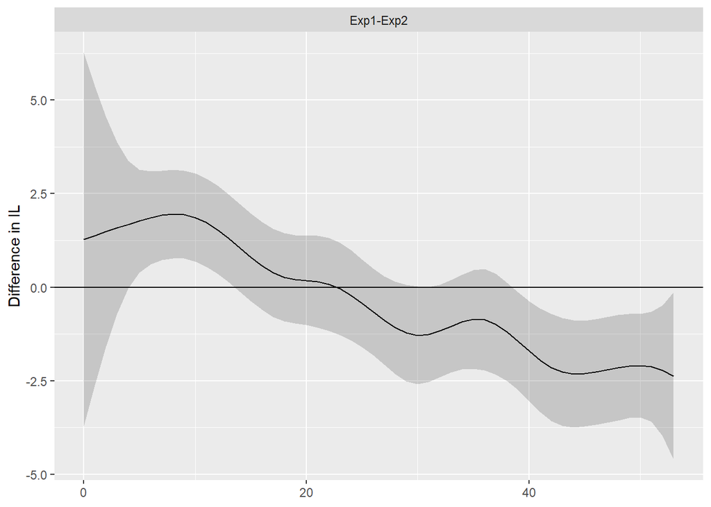

**NB!** По-моему, с этой части лучше начать изложение результатов в статье, чтобы дать описание того, как изменяется обилие паразитов в зависисомсти от DPI. А уже потом перейти к динамике физиологических характеристик (которая в данном документе описана выше).

# Третий этап анализа

Описание связи физиолгических характеристик птиц с “популяционными” процессами паразита

## Связь RMR с накопленной паразитемией

```r
M1_RMR_Par_gam <- gam(log(RMR) ~ s(Cum_Parasitemia, k = 4) + Experiment + log(Mass)  + s(Ring, k = 53, bs = "re"),  method = "REML", data = finch_reduced %>% filter(Experiment != "Cont"))

M2_RMR_Par_gam <- gam(log(RMR) ~ s(Cum_Parasitemia, by = Experiment, k = 4) + Experiment + log(Mass)  + s(Ring, k = 53, bs = "re"),  method = "REML", data = finch_reduced %>% filter(Experiment != "Cont"))
```

```r
AIC(M1_RMR_Par_gam, M2_RMR_Par_gam)
```

```
##                      df       AIC
## M1_RMR_Par_gam 28.74482 -205.0115
## M2_RMR_Par_gam 30.95193 -198.2504
```

В данном случае получается, что модель с общим смузером для двух групп оказывается лучше.

Проверка валидности

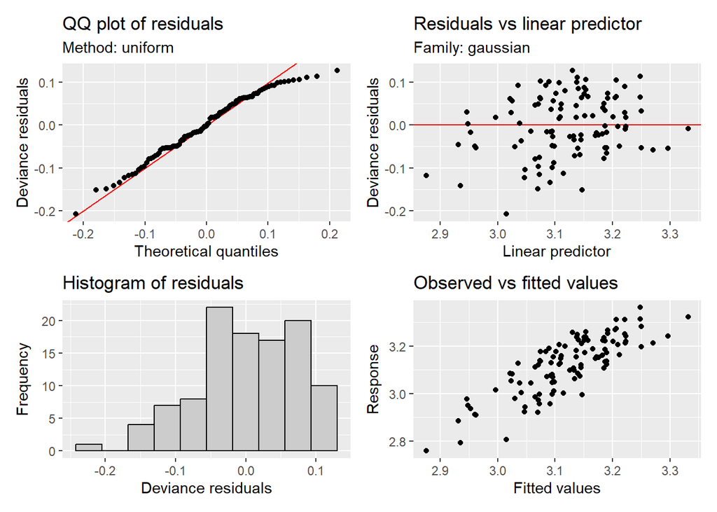

```r
appraise(M1_RMR_Par_gam)
```

Описание модели

```
##
## Family: gaussian
## Link function: identity
##
## Formula:
## log(RMR) ~ s(Cum_Parasitemia, k = 4) + Experiment + log(Mass) +
##     s(Ring, k = 53, bs = "re")
##
## Parametric coefficients:
##                Estimate Std. Error t value Pr(>|t|)
## (Intercept)     1.57797    0.34036   4.636 1.35e-05 ***
## ExperimentExp2  0.06912    0.03084   2.241   0.0278 *
## log(Mass)       0.59377    0.13409   4.428 2.96e-05 ***
## ---
## Signif. codes:  0 '***' 0.001 '**' 0.01 '*' 0.05 '.' 0.1 ' ' 1
##
## Approximate significance of smooth terms:
##                       edf Ref.df     F  p-value
## s(Cum_Parasitemia)  2.818  2.954 12.57 6.97e-07 ***
## s(Ring)            20.548 32.000  2.19 6.41e-06 ***
## ---
## Signif. codes:  0 '***' 0.001 '**' 0.01 '*' 0.05 '.' 0.1 ' ' 1
##
## R-sq.(adj) =  0.551   Deviance explained = 65.8%
## -REML = -84.693  Scale est. = 0.0066826  n = 107
```

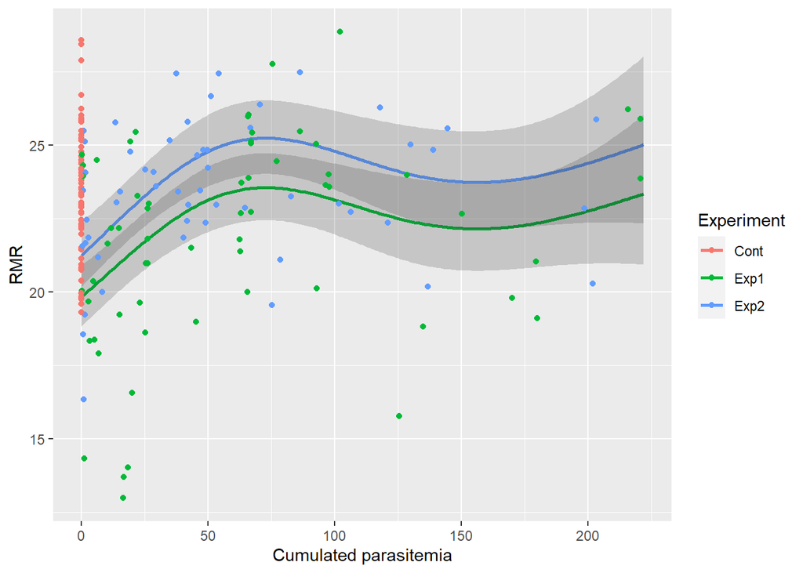

Что видно.

1. При заражении Exp2, в среднем, RMR *немного* выше, чем чем при заражении Exp1.
2. По мере увеличения циклов мерогонии (накопленная паразитемия) при заражении и тем, и другим видом паразитов RMR не остается постоянным (смузеры не нулевые). То есть RMR *зависит* от накопленной парзитемии.
3. RMR на первых этапах заболевания возрастает, но потом остается более или менее стабильным.

## Связь IL с накопленной паразитемией

```r
M1_IL_Par_gam <- gam(log(IL) ~ s(Cum_Parasitemia, k = 4) + Experiment + log(Mass)  + s(Ring, k = 53, bs = "re"),  method = "REML", data = finch_reduced %>% filter(Experiment != "Cont"))

M2_IL_Par_gam <- gam(log(IL) ~ s(Cum_Parasitemia, by = Experiment, k = 4) + Experiment + log(Mass)  + s(Ring, k = 53, bs = "re"),  method = "REML", data = finch_reduced %>% filter(Experiment != "Cont"))
```

```r
AIC(M1_IL_Par_gam, M2_IL_Par_gam)
```

[output not shown]

Проверка валидности

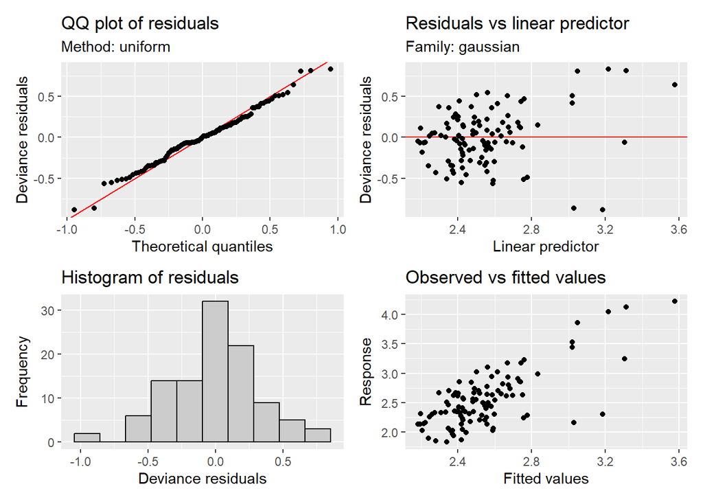

Описание модели

```
##
## Family: gaussian
## Link function: identity
##
## Formula:
## log(IL) ~ s(Cum_Parasitemia, k = 4) + Experiment + log(Mass) +
##     s(Ring, k = 53, bs = "re")
##
## Parametric coefficients:
##                Estimate Std. Error t value Pr(>|t|)
## (Intercept)     -1.4313     1.4102  -1.015  0.31298
## ExperimentExp2  -0.1488     0.1167  -1.275  0.20570
## log(Mass)        1.5805     0.5550   2.848  0.00551 **
## ---
## Signif. codes:  0 '***' 0.001 '**' 0.01 '*' 0.05 '.' 0.1 ' ' 1
##
## Approximate significance of smooth terms:
##                      edf Ref.df     F  p-value
## s(Cum_Parasitemia)  1.00      1 1.502 0.223751
## s(Ring)            17.25     32 1.471 0.000182 ***
## ---
## Signif. codes:  0 '***' 0.001 '**' 0.01 '*' 0.05 '.' 0.1 ' ' 1
##
## R-sq.(adj) =  0.377   Deviance explained = 49.6%
## -REML = 61.765  Scale est. = 0.13327   n = 107
```

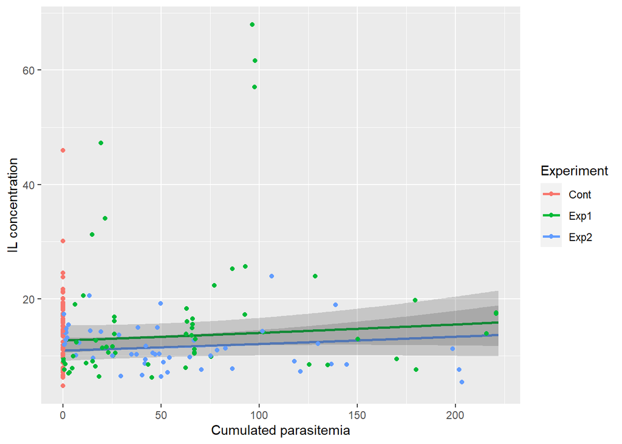

Что видно.  
1. При заражении Exp1, в среднем, концентрация IL выше, чем чем при заражении Exp2.

2. По мере увеличения циклов мерогонии (накопленная паразитемия) при заражении и тем, и другим видом паразитов концентрация IL остается более или менее постоянной (нулевой смузер).

Надо подумать теперь, как поженить этот результат с тем, где разница в концентрациях интерлейкина у Exp1 vs Exp2 меняется в зависимости от DPI (см. выше). Возможно тут надо апеллировать к тому, что накопленная паразитемия лучше отражает *индивидуальный* ход заболевания, в то время как DPI характеризует, скорее, *групповой* (то есть видоспецифический в отношении вида птицы) ответ.

#### Дополнение

Не лишним будет описать связь между концентрацией IL и паразитемией (не накопленной, а просто, в данный момент).

Вот так выглядит эта связь (это визуализация LMM модели).

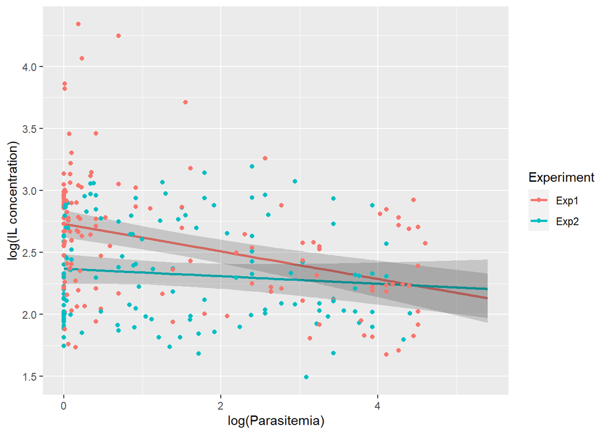

Видно, что при разных видах паразитов связь концентрации интерлейкинов с паразитемией разная. В случае с Exp2 связи не наблюдается. В случае с Exp1 прослеживается отрицательная зависимость. То есть, чем больше мерозоитов, тем меньше интерлейкинов. Может быть здесь надо эту связь читать наоборот - высокая паразитемия может быть только при низком интерлейкине, когда иммунитет не тормозит мерогонию.

Надо думать…